# Advanced Stats Project Group 2

# ADVANCED BUSINESS STATISTICS

## RESEARCH PROPOSAL

### Predictive Modelling of Credit Card Approval and Its Impact on Risk Assessment in Financial Institutions

#### (Goutham Yallapu, Ruhi Fareeda, Sri Ram, Bahauddin Quraishi Abdallah)

## Introduction and Background:

Credit card approval is a critical component of financial services, and it involves a multifaceted evaluation of applicants’ eligibility. Financial institutions must carefully assess various factors like income, age, employment history, etc. when making lending decisions, as these determinations have far-reaching implications for both borrowers and lenders. Ultimately, this research endeavours to offer both practical implications for financial institutions and valuable contributions to the body of knowledge surrounding credit risk assessment and lending disparities.

## Research Objectives and Methodology:

The research question of this paper involves the prediction of whether or not a person will be approved for a credit card. Its main goal is to make it easier to analyse credit risk, particularly in the context of credit card approval, by incorporating a wide range of variables and attributes related to credit card applicants in the dataset. - What are the key demographic and financial factors that significantly influence the approval or denial of credit card applications? - How does the approval rate for credit card applications vary across different demographic groups, such as income levels, family backgrounds, and age brackets?

## Data:

For this research, we have used the dataset from “Kaggle” which is “Credit Card Approval Prediction” including the applicant’s general information such as name, age, gender, educational level, financial information like income, and occupation which in turn has observations up to 25,128 from each category. The dataset can be used for practicing Exploratory Data Analysis (EDA) techniques to understand the distribution of variables, identify trends and patterns, and explore relationships between variables.

## References:

https://www.kaggle.com/datasets/caesarmario/application-data

## LITERATURE REVIEW

Credit card lending is a major service offered by banks and financial institutions convenience and financing to consumers. A key element of financial services is credit card acceptance, which necessitates a thorough assessment of applicants’ eligibility. When deciding whether to make a loan, financial institutions must carefully consider a number of aspects because these choices have repercussions that affect both borrowers and lenders, where we forecast whether or not a person would be given a credit card.

In our paper, we have included a wide range of characteristics and traits connected to credit card applicants in the dataset and it aims to simplify the analysis of credit risk, particularly in the context of credit card approval . The recent study by IJCSE students provided useful background on supervised learning techniques for credit card approval prediction using a similar application dataset. They heavily emphasized on credit score as a key variable, and utilized logistic regression for modeling (IJCSE students, 2022). However, the study focused more on the credit scores including concepts of logistic regression. In our study, we will incorporate a wider set of application attributes beyond just credit score data.

Moreover, Ryan Kuhn’s work demonstrates the value of exploratory data analysis (EDA) techniques when working with real-world credit application data (Kuhn, 2020). EDA allows identifying missing data and outliers that could skew models if not properly handled. In our study, we will utilize EDA techniques to deeply understand our application data, uncover issues, and determine appropriate data preprocessing steps and also which can help us forecast credit approval by finding missing data and choosing the best method to fix them.

## Data Gathering

We have gathered the dataset from Kaggle website named as ‘Credit Card Approval Prediction’[link](https://www.kaggle.com/datasets/caesarmario/application-data)which comprises a collection of 25,128 observations, each representing an status of an individual credit card application. This dataset offers a comprehensive view of applicants’ demographic, financial, and employment information, as well as the outcomes of their credit card applications. Analyzing this dataset can provide valuable insights into the factors that significantly influence the approval or denial of credit card applications, helping financial institutions make informed decisions and applicants understand their eligibility.

```r
library(readxl)
credit_approval_project <- read.csv("D:/Goutham/Mercer University/5. Advanced Business Statistics/Project/3. Project/V3/Application_Data.csv")
```

## Data Dictionary

Here is a brief description of every variable that is included in our dataset.

[output not shown]

```r
str(credit_approval_project)
```

```
## 'data.frame':    25128 obs. of  21 variables:
##  $ Applicant_ID        : int  5008806 5008808 5008809 5008810 5008811 5008815 5008819 5008820 5008821 5008822 ...
##  $ Applicant_Gender    : chr  "M      " "F      " "F      " "F      " ...
##  $ Owned_Car           : int  1 0 0 0 0 1 1 1 1 1 ...
##  $ Owned_Realty        : int  1 1 1 1 1 1 1 1 1 1 ...
##  $ Total_Children      : int  0 0 0 0 0 0 0 0 0 0 ...
##  $ Total_Income        : int  112500 270000 270000 270000 270000 270000 135000 135000 135000 135000 ...
##  $ Income_Type         : chr  "Working                                           " "Commercial associate                              " "Commercial associate                              " "Commercial associate                              " ...
##  $ Education_Type      : chr  "Secondary / secondary special                     " "Secondary / secondary special                     " "Secondary / secondary special                     " "Secondary / secondary special                     " ...
##  $ Family_Status       : chr  "Married                                           " "Single / not married                              " "Single / not married                              " "Single / not married                              " ...
##  $ Housing_Type        : chr  "House / apartment                                 " "House / apartment                                 " "House / apartment                                 " "House / apartment                                 " ...
##  $ Owned_Mobile_Phone  : int  1 1 1 1 1 1 1 1 1 1 ...
##  $ Owned_Work_Phone    : int  0 0 0 0 0 1 0 0 0 0 ...
##  $ Owned_Phone         : int  0 1 1 1 1 1 0 0 0 0 ...
##  $ Owned_Email         : int  0 1 1 1 1 1 0 0 0 0 ...
##  $ Job_Title           : chr  "Security staff                                    " "Sales staff                                       " "Sales staff                                       " "Sales staff                                       " ...
##  $ Total_Family_Members: int  2 1 1 1 1 2 2 2 2 2 ...
##  $ Applicant_Age       : int  59 53 53 53 53 47 49 49 49 49 ...
##  $ Years_of_Working    : int  4 9 9 9 9 3 4 4 4 4 ...
##  $ Total_Bad_Debt      : int  0 0 0 0 0 0 0 0 0 0 ...
##  $ Total_Good_Debt     : int  30 5 5 27 39 6 8 9 9 9 ...
##  $ Status              : int  1 1 1 1 1 1 1 1 1 1 ...
```

```r
number_of_obs <- nrow(credit_approval_project)
number_of_var <- ncol(credit_approval_project)

cat("There are ", number_of_obs,"observations ")
```

```
## There are  25128 observations
```

## Data Cleaning

Data cleaning and preprocessing are essential steps in the part of data analysis. These procedures are critical for assuring the dataset’s dependability and quality, as well as preparing it for analysis and modeling. In the context of the Credit Card Application Dataset, data cleaning and preprocessing are critical to optimize the dataset for addressing research questions and making data-driven choices.

## Reducing the data dimensions

Reducing the dimensionality of a dataset involves eliminating variables that might not contribute significant information to the analysis. This practice simplifies the dataset, enhances the interpretability, reduces the risk of overfitting, and can lead to more efficient computational processing. Especially in large datasets, variables like ‘Owned_Mobile phone’ might not provide meaningful insights into the specific problem at hand. By removing such irrelevant variables, the data becomes streamlined, leading to a more focused and effective analysis.

### Exploratory Data Analysis

```r
head(credit_approval_project)
```

```
##   Applicant_ID Applicant_Gender Owned_Car Owned_Realty Total_Children
## 1      5008806          M               1            1              0
## 2      5008808          F               0            1              0
## 3      5008809          F               0            1              0
## 4      5008810          F               0            1              0
## 5      5008811          F               0            1              0
## 6      5008815          M               1            1              0
##   Total_Income                                        Income_Type
## 1       112500 Working
## 2       270000 Commercial associate
## 3       270000 Commercial associate
## 4       270000 Commercial associate
## 5       270000 Commercial associate
## 6       270000 Working
##                                       Education_Type
```

[output cut: 41 more lines]

```r
summary(credit_approval_project)
```

```
##   Applicant_ID     Applicant_Gender     Owned_Car       Owned_Realty
##  Min.   :5008806   Length:25128       Min.   :0.0000   Min.   :0.0000
##  1st Qu.:5042226   Class :character   1st Qu.:0.0000   1st Qu.:0.0000
##  Median :5079004   Mode  :character   Median :0.0000   Median :1.0000
##  Mean   :5078835                      Mean   :0.4184   Mean   :0.6549
##  3rd Qu.:5115603                      3rd Qu.:1.0000   3rd Qu.:1.0000
##  Max.   :5150487                      Max.   :1.0000   Max.   :1.0000
##  Total_Children    Total_Income     Income_Type        Education_Type
##  Min.   :0.0000   Min.   :  27000   Length:25128       Length:25128
##  1st Qu.:0.0000   1st Qu.: 135000   Class :character   Class :character
##  Median :0.0000   Median : 180000   Mode  :character   Mode  :character
##  Mean   :0.5095   Mean   : 194837
##  3rd Qu.:1.0000   3rd Qu.: 225000
##  Max.   :5.0000   Max.   :1575000
##  Family_Status      Housing_Type       Owned_Mobile_Phone Owned_Work_Phone
##  Length:25128       Length:25128       Min.   :1          Min.   :0.0000
##  Class :character   Class :character   1st Qu.:1          1st Qu.:0.0000
##  Mode  :character   Mode  :character   Median :1          Median :0.0000
##                                        Mean   :1          Mean   :0.2738
##                                        3rd Qu.:1          3rd Qu.:1.0000
##                                        Max.   :1          Max.   :1.0000
##   Owned_Phone      Owned_Email      Job_Title         Total_Family_Members
##  Min.   :0.0000   Min.   :0.0000   Length:25128       Min.   :1.000
##  1st Qu.:0.0000   1st Qu.:0.0000   Class :character   1st Qu.:2.000
##  Median :0.0000   Median :0.0000   Mode  :character   Median :2.000
##  Mean   :0.2927   Mean   :0.1007                      Mean   :2.291
##  3rd Qu.:1.0000   3rd Qu.:0.0000                      3rd Qu.:3.000
##  Max.   :1.0000   Max.   :1.0000                      Max.   :7.000
##  Applicant_Age Years_of_Working Total_Bad_Debt    Total_Good_Debt
##  Min.   :21    Min.   : 1.000   Min.   : 0.0000   Min.   : 1.00
##  1st Qu.:33    1st Qu.: 3.000   1st Qu.: 0.0000   1st Qu.: 9.00
##  Median :40    Median : 6.000   Median : 0.0000   Median :18.00
##  Mean   :41    Mean   : 7.691   Mean   : 0.3331   Mean   :21.06
##  3rd Qu.:48    3rd Qu.:10.000   3rd Qu.: 0.0000   3rd Qu.:31.00
##  Max.   :68    Max.   :44.000   Max.   :49.0000   Max.   :61.00
##      Status
##  Min.   :0.0000
##  1st Qu.:1.0000
##  Median :1.0000
##  Mean   :0.9952
##  3rd Qu.:1.0000
##  Max.   :1.0000
```

Below we can see the data type of variables

```r
str(credit_approval_project)
```

```
## 'data.frame':    25128 obs. of  21 variables:
##  $ Applicant_ID        : int  5008806 5008808 5008809 5008810 5008811 5008815 5008819 5008820 5008821 5008822 ...
##  $ Applicant_Gender    : chr  "M      " "F      " "F      " "F      " ...
##  $ Owned_Car           : int  1 0 0 0 0 1 1 1 1 1 ...
##  $ Owned_Realty        : int  1 1 1 1 1 1 1 1 1 1 ...
##  $ Total_Children      : int  0 0 0 0 0 0 0 0 0 0 ...
##  $ Total_Income        : int  112500 270000 270000 270000 270000 270000 135000 135000 135000 135000 ...
##  $ Income_Type         : chr  "Working                                           " "Commercial associate                              " "Commercial associate                              " "Commercial associate                              " ...
##  $ Education_Type      : chr  "Secondary / secondary special                     " "Secondary / secondary special                     " "Secondary / secondary special                     " "Secondary / secondary special                     " ...
##  $ Family_Status       : chr  "Married                                           " "Single / not married                              " "Single / not married                              " "Single / not married                              " ...
##  $ Housing_Type        : chr  "House / apartment                                 " "House / apartment                                 " "House / apartment                                 " "House / apartment                                 " ...
##  $ Owned_Mobile_Phone  : int  1 1 1 1 1 1 1 1 1 1 ...
##  $ Owned_Work_Phone    : int  0 0 0 0 0 1 0 0 0 0 ...
##  $ Owned_Phone         : int  0 1 1 1 1 1 0 0 0 0 ...
##  $ Owned_Email         : int  0 1 1 1 1 1 0 0 0 0 ...
##  $ Job_Title           : chr  "Security staff                                    " "Sales staff                                       " "Sales staff                                       " "Sales staff                                       " ...
##  $ Total_Family_Members: int  2 1 1 1 1 2 2 2 2 2 ...
##  $ Applicant_Age       : int  59 53 53 53 53 47 49 49 49 49 ...
##  $ Years_of_Working    : int  4 9 9 9 9 3 4 4 4 4 ...
##  $ Total_Bad_Debt      : int  0 0 0 0 0 0 0 0 0 0 ...
##  $ Total_Good_Debt     : int  30 5 5 27 39 6 8 9 9 9 ...
##  $ Status              : int  1 1 1 1 1 1 1 1 1 1 ...
```

## Finding Missing data

Missing values or lack of data for certain observations or variables, are common issues in data analysis and can have a substantial influence on the quality and dependability of analytical conclusions. Handling missing values is an important step in data preparation since it has a direct impact on the quality and validity of the analysis and models. In this section, we’ll look at the significance of missing values.

```r
missing_values <- sum(is.na(credit_approval_project))

cat("There are ", missing_values,"missing observations in the dataset")
```

```
## There are  0 missing observations in the dataset
```

### Converting data types

A key operation in programming and data manipulation is data type conversion. It entails converting a variable’s or value’s data type from one kind to another. Because different data types serve distinct functions and have varying storage needs and behaviors, this approach is crucial.

```r
# Converting Categorical data
credit_approval_project$Applicant_Gender <-as.factor(credit_approval_project$Applicant_Gender)
credit_approval_project$Income_Type <- as.factor(credit_approval_project$Income_Type)
credit_approval_project$Education_Type <- as.factor(credit_approval_project$Education_Type)

# Converting numeric data
credit_approval_project$Total_Income <- as.numeric(credit_approval_project$Total_Income)
credit_approval_project$Applicant_Age <- as.numeric(credit_approval_project$Applicant_Age)
credit_approval_project$Years_of_Working <- as.numeric(credit_approval_project$Years_of_Working)
credit_approval_project$Total_Bad_Debt <- as.numeric(credit_approval_project$Total_Bad_Debt)
credit_approval_project$Total_Good_Debt <- as.numeric(credit_approval_project$Total_Good_Debt)

# Converting Binary data
credit_approval_project$Status <- as.factor(credit_approval_project$Status)


str(credit_approval_project)
```

```
## 'data.frame':    25128 obs. of  21 variables:
##  $ Applicant_ID        : int  5008806 5008808 5008809 5008810 5008811 5008815 5008819 5008820 5008821 5008822 ...
##  $ Applicant_Gender    : Factor w/ 2 levels "F      ","M      ": 2 1 1 1 1 2 2 2 2 2 ...
##  $ Owned_Car           : int  1 0 0 0 0 1 1 1 1 1 ...
##  $ Owned_Realty        : int  1 1 1 1 1 1 1 1 1 1 ...
##  $ Total_Children      : int  0 0 0 0 0 0 0 0 0 0 ...
##  $ Total_Income        : num  112500 270000 270000 270000 270000 ...
##  $ Income_Type         : Factor w/ 5 levels "Commercial associate                              ",..: 5 1 1 1 1 5 1 1 1 1 ...
##  $ Education_Type      : Factor w/ 5 levels "Academic degree                                   ",..: 5 5 5 5 5 2 5 5 5 5 ...
##  $ Family_Status       : chr  "Married                                           " "Single / not married                              " "Single / not married                              " "Single / not married                              " ...
##  $ Housing_Type        : chr  "House / apartment                                 " "House / apartment                                 " "House / apartment                                 " "House / apartment                                 " ...
##  $ Owned_Mobile_Phone  : int  1 1 1 1 1 1 1 1 1 1 ...
##  $ Owned_Work_Phone    : int  0 0 0 0 0 1 0 0 0 0 ...
##  $ Owned_Phone         : int  0 1 1 1 1 1 0 0 0 0 ...
##  $ Owned_Email         : int  0 1 1 1 1 1 0 0 0 0 ...
##  $ Job_Title           : chr  "Security staff                                    " "Sales staff                                       " "Sales staff                                       " "Sales staff                                       " ...
##  $ Total_Family_Members: int  2 1 1 1 1 2 2 2 2 2 ...
##  $ Applicant_Age       : num  59 53 53 53 53 47 49 49 49 49 ...
##  $ Years_of_Working    : num  4 9 9 9 9 3 4 4 4 4 ...
##  $ Total_Bad_Debt      : num  0 0 0 0 0 0 0 0 0 0 ...
##  $ Total_Good_Debt     : num  30 5 5 27 39 6 8 9 9 9 ...
##  $ Status              : Factor w/ 2 levels "0","1": 2 2 2 2 2 2 2 2 2 2 ...
```

## Data Visualization

A boxplot is used here to visualize and compare the distribution of “Total Good Debt” across different “Status” categories. It’s a compact and effective choice because it displays key statistics, highlights outliers, and facilitates easy categorical comparisons, making it ideal for this analysis.

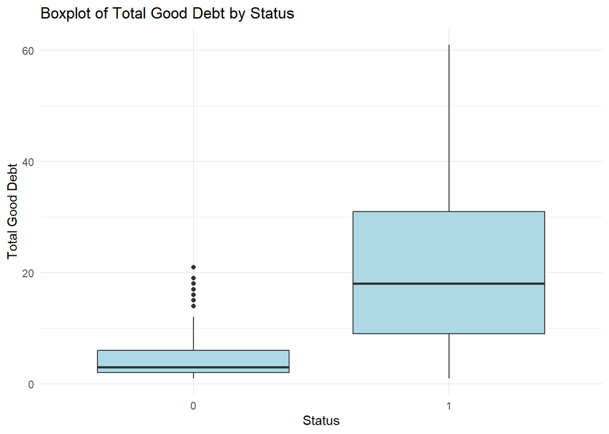

```r
library("ggplot2")

boxplot1 <- ggplot(credit_approval_project, aes(x = Status, y = Total_Good_Debt)) +
  geom_boxplot(fill = "lightblue") +
  labs(title = "Boxplot of Total Good Debt by Status", x = "Status", y = "Total Good Debt") +
  theme_minimal()

print(boxplot1)
```

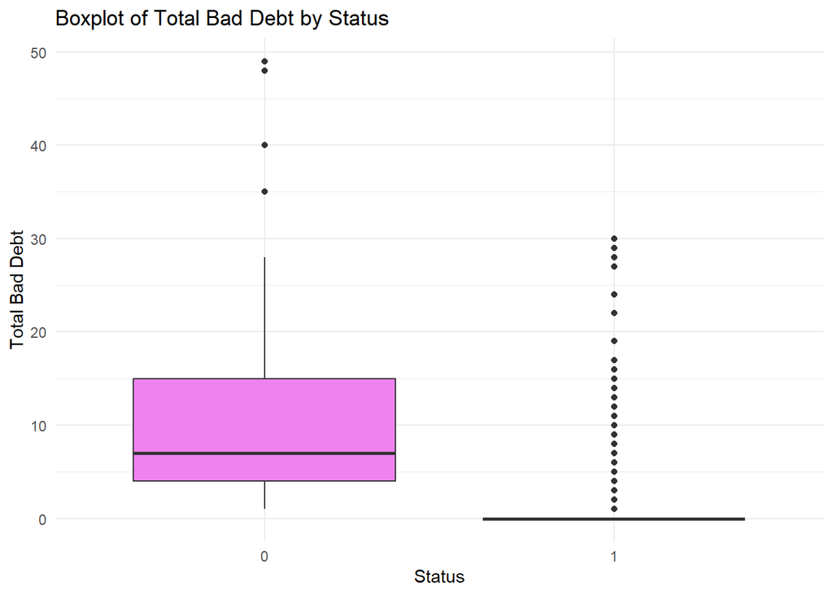

```r
boxplot2 <- ggplot(credit_approval_project, aes(x = Status, y = Total_Bad_Debt)) +
  geom_boxplot(fill = "violet") +
  labs(title = "Boxplot of Total Bad Debt by Status", x = "Status", y = "Total Bad Debt") +
  theme_minimal()

print(boxplot2)
```

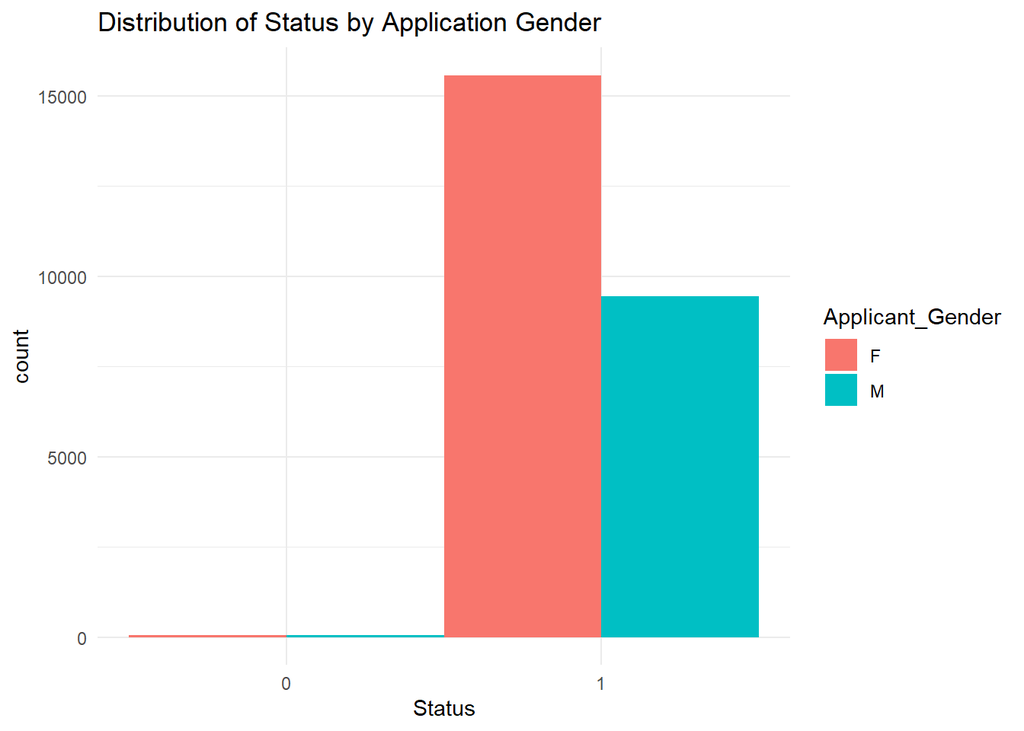

```r
boxplot3 <- ggplot(credit_approval_project, aes(x = Status, fill = Applicant_Gender)) +
  geom_bar(width = 1, position = "dodge") +
  labs(title = "Distribution of Status by Application Gender", x = "Status") +
  theme_minimal()

boxplot3
```

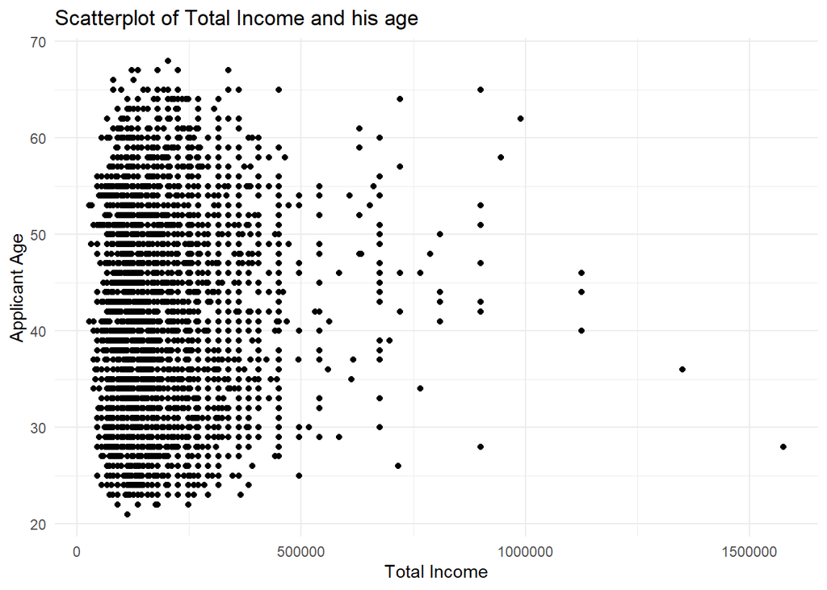

```r
scatterplot <- ggplot(credit_approval_project, aes(x = Total_Income, y = Applicant_Age)) +
  geom_point() +
  labs(title = "Scatterplot of Total Income and his age", x = "Total Income", y = "Applicant Age") +
  theme_minimal()

print(scatterplot)
```

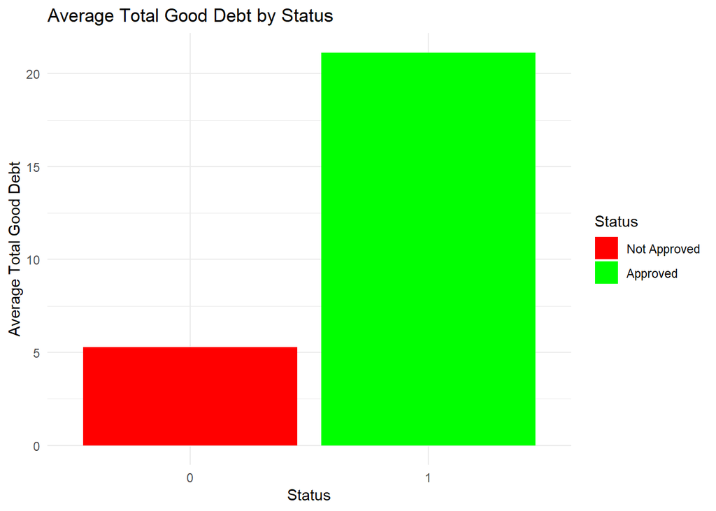

```r
barplot_good_debt <- ggplot(credit_approval_project, aes(x = Status, y = Total_Good_Debt, fill = Status)) +
  geom_bar(stat = "summary", fun = "mean") +
  labs(title = "Average Total Good Debt by Status", x = "Status", y = "Average Total Good Debt") +
  scale_fill_manual(values = c("red", "green"), labels = c("Not Approved", "Approved")) +
  theme_minimal()

print(barplot_good_debt)
```

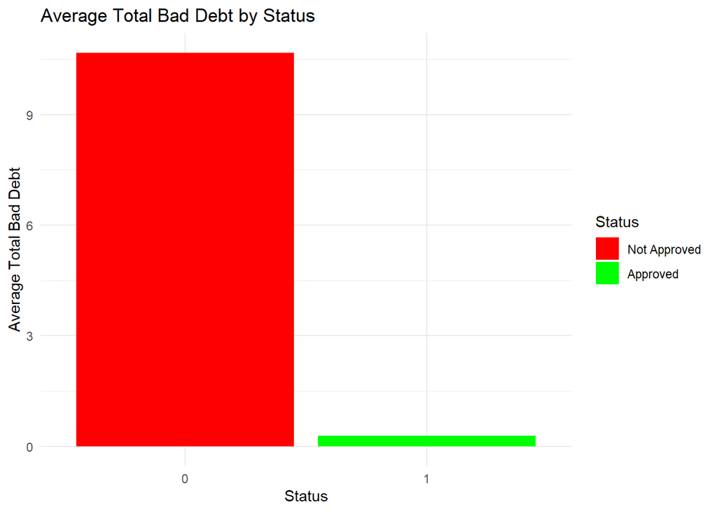

```r
barplot_bad_debt <- ggplot(credit_approval_project, aes(x = Status, y = Total_Bad_Debt, fill = Status)) +
  geom_bar(stat = "summary", fun = "mean") +
  labs(title = "Average Total Bad Debt by Status", x = "Status", y = "Average Total Bad Debt") +
  scale_fill_manual(values = c("red", "green"), labels = c("Not Approved", "Approved")) +
  theme_minimal()

print(barplot_bad_debt)
```

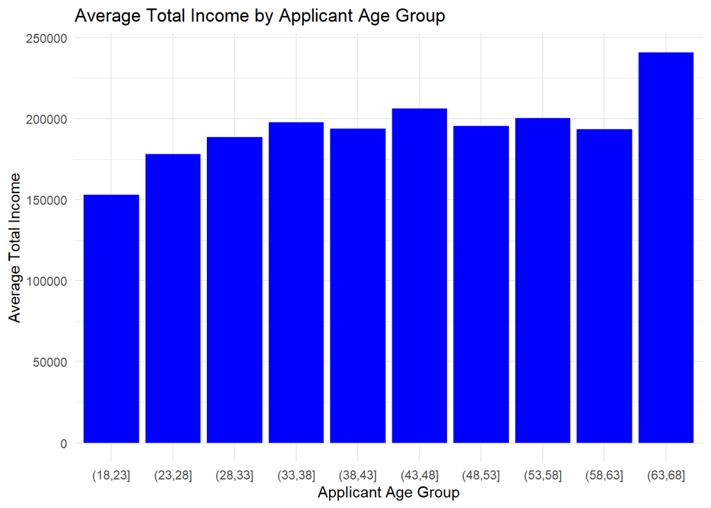

```r
barplot_income_age <- ggplot(credit_approval_project, aes(x = cut(Applicant_Age, breaks = seq(18, 80, by = 5)), y = Total_Income)) +
  geom_bar(stat = "summary", fun = "mean", fill = "blue") +
  labs(title = "Average Total Income by Applicant Age Group", x = "Applicant Age Group", y = "Average Total Income") +
  theme_minimal()

print(barplot_income_age)
```

### Summary or Brief Interpretation of the visualization

In summary, the visuals are useful for seeing distributions of financial variables that likely impact credit approval and how they differ between approved and non-approved applicants. They also show basic demographic breakdowns. Exploring the relationships visually is helpful before building statistical models.

## Econometric model and Techniques

Dependent variable: Status Independent variable: Total Good debt, Total bad debt

### What are the key demographic and financial factors that significantly influence the approval or denial of credit card applications?

#### **Logistic Regression**

Logistic regression is a widely used statistical technique for modeling the relationship between a binary outcome variable and one or more predictor variables. It is particularly valuable in situations where you want to understand and predict the probability of an event occurring.

```r
library(dplyr)
library(caret)
library(stargazer)
library(kableExtra)
library(broom)

set.seed(123)

Regression <- glm(credit_approval_project$Status ~ Total_Good_Debt + Total_Bad_Debt , data = credit_approval_project, family = "binomial")

summary(Regression)
```

```
##
## Call:
## glm(formula = credit_approval_project$Status ~ Total_Good_Debt +
##     Total_Bad_Debt, family = "binomial", data = credit_approval_project)
##
## Coefficients:
##                 Estimate Std. Error z value Pr(>|z|)
## (Intercept)       -14.83     201.51  -0.074    0.941
## Total_Good_Debt    31.51     240.90   0.131    0.896
## Total_Bad_Debt    -31.58     239.32  -0.132    0.895
##
## (Dispersion parameter for binomial family taken to be 1)
##
##     Null deviance: 1.5327e+03  on 25127  degrees of freedom
## Residual deviance: 5.4921e-05  on 25125  degrees of freedom
## AIC: 6.0001
##
## Number of Fisher Scoring iterations: 25
```

```r
stargazer(Regression, type = "text",
          title="Logistic Regression",
          digits=5)
```

```
##
## Logistic Regression
## =============================================
##                       Dependent variable:
##                   ---------------------------
##                             Status
## ---------------------------------------------
## Total_Good_Debt            31.51219
##                           (240.90240)
##
## Total_Bad_Debt             -31.58138
##                           (239.31520)
##
## Constant                   -14.83110
##                           (201.50530)
##
## ---------------------------------------------
## Observations                25,128
## Log Likelihood             -0.00003
## Akaike Inf. Crit.           6.00005
## =============================================
## Note:             *p<0.1; **p<0.05; ***p<0.01
```

```r
## Likelihood Ratio test
library(lmtest)

null_model3 <- glm(formula = Status ~ 1, family = "binomial", data = credit_approval_project)

model3 <- glm(formula = Status ~ Total_Good_Debt + Total_Bad_Debt, family = "binomial", data = credit_approval_project)

Likelihood_test <- lrtest(null_model3, model3)

kable(tidy(Likelihood_test), digits=5, align="c",
      caption="Likelihood test for the Good debt and Bad debt")%>%
    kable_styling(full_width = T)
```

Likelihood test for the Good debt and Bad debt

| term | X.Df | LogLik | df | statistic | p.value |
| --- | --- | --- | --- | --- | --- |
| Status ~ 1 | 1 | -766.35785 | NA | NA | NA |
| Status ~ Total_Good_Debt + Total_Bad_Debt | 3 | -0.00003 | 2 | 1532.716 | 0 |

The likelihood ratio test (lrtest) is used to compare the fit of two models. In this case, it’s comparing the Model 1 with no predictor variables to Model 2 with “Total_Good_Debt” and “Total_Bad_Debt” as predictors.

The log likelihood (LogLik) is a measure of how well the model fits the data. Model 2 has a higher log likelihood (-0.00003) compared to Model 1 (-766.35785), indicating that Model 2 fits the data much better.

The statistic (1532.716) is a test statistic that quantifies the difference in model fit between Model 1 and Model 2.

The p-value associated with the test statistic is 0, which is very low. In hypothesis testing, a low p-value indicates that the difference in fit between the two models is statistically significant.

Therefore, the results suggest that Model 2, which includes “Total_Good_Debt” and “Total_Bad_Debt” as predictors, is a significantly better fit for the data compared to Model 1, which does not include any predictors. In other words, these predictor variables are providing valuable information in explaining the “Status.”

#### **Chi-Square Test**

Chi-Square test is a valuable tool for understanding whether there is a significant relationship or independence between two or more categorical variables within a dataset.

```r
# Creating crosstabulation table
table2 <- table(credit_approval_project$Total_Good_Debt, credit_approval_project$Status)
table3 <- table(credit_approval_project$Total_Bad_Debt, credit_approval_project$Status)

# Running chi-squared test
chisq_test2 <- chisq.test(table2)
chisq_test3 <- chisq.test(table3)

summary_table <- data.frame(
  Variable = c("Good debts", "Bad debts"),
  Chi_Squared = c(chisq_test2$statistic, chisq_test3$statistic),
  P_Value = c(chisq_test2$p.value, chisq_test3$p.value)
)

write.csv(summary_table, file = "credit_approval_project.csv", row.names = TRUE)

stargazer(summary_table, type = "text",
          title="Chi-Square test",
          summary = FALSE,
          digits=5)
```

```
##
## Chi-Square test
## ================================
##    Variable  Chi_Squared P_Value
## --------------------------------
## 1 Good debts  624.36920     0
## 2 Bad debts  7,303.63500    0
## --------------------------------
```

The Chi-Square test is a statistical test used to determine if there is an association between two categorical variables. For “Good debts,” the Chi-Square value of 624.36920 and a p-value of 0 indicate that there is a significant association between the variable “Good debts” and the outcome being tested.In the same way, “Bad debts,” the Chi-Square value is much higher (7,303.6350) than for “Good debts,” and the p-value is 0, which also suggests a very significant association between “Bad debts” and the outcome.

In both cases, the very low p-values indicate that these variables are strongly associated with the outcome being tested. This implies that “Good debts” and “Bad debts” are likely to have a substantial impact on the outcome, and they are not independent of each other.

So, to answer our first research question we we will be proceeding with Logistic Regression with lrtest, which enables us to clearly figure out the impact and magnitude of the effects of financial varaibles like Total Bad debt and Total good debt.

### How does the approval rate for credit card applications vary across different demographic groups, such as income levels, family backgrounds, and age brackets?

Dependent variable: Status Independent variable: Income Type, Family Member, Years of Working, Applicant age

```r
#Logistic regression

Regression2 <- glm(credit_approval_project$Status ~ Income_Type + Total_Family_Members + Years_of_Working + Applicant_Age, data = credit_approval_project, family = "binomial")


stargazer(Regression2, type = "text",
          title="Logistic Regression",
          summary = FALSE,
          digits=5)
```

```
##
## Logistic Regression
## ====================================================
##                              Dependent variable:
##                          ---------------------------
##                                    Status
## ----------------------------------------------------
## Income_TypePensioner             -4.40367***
##                                   (0.62932)
##
## Income_TypeState servant          0.73164*
##                                   (0.43853)
##
## Income_TypeStudent                10.23169
##                                  (459.29550)
##
## Income_TypeWorking                0.32804*
##                                   (0.19490)
##
## Total_Family_Members              0.18571*
##                                   (0.10439)
##
## Years_of_Working                 0.05889***
##                                   (0.02035)
##
## Applicant_Age                      0.00872
##                                   (0.00998)
##
## Constant                         3.96333***
##                                   (0.48830)
##
## ----------------------------------------------------
## Observations                       25,128
## Log Likelihood                   -741.49240
## Akaike Inf. Crit.                1,498.98500
## ====================================================
## Note:                    *p<0.1; **p<0.05; ***p<0.01
```

#### **ANOVA**

ANOVA, which stands for Analysis of Variance, is a statistical technique used to compare the means of different groups or categories in a dataset. It is a flexible and effective technique for determining how one or more independent factors influence a dependent variable. ANOVA assists researchers in determining if data variance may be attributable to group differences rather than random fluctuation or measurement error.

```r
# Anova test
credit_approval_project2 <- read.csv("D:/Goutham/Mercer University/5. Advanced Business Statistics/Project/3. Project/V3/Application_Data.csv")

anova_test <- aov(Status ~ Income_Type + Years_of_Working + Total_Family_Members + Applicant_Age, data = credit_approval_project2)


kable(tidy(anova_test), digits=5, align="c",
      caption="Logit estimates for the Credit approval dataset")%>%
    kable_styling(full_width = T)
```

| term | df | sumsq | meansq | statistic | p.value |
| --- | --- | --- | --- | --- | --- |
| Income_Type | 4 | 1.22488 | 0.30622 | 64.57094 | 0.00000 |
| Years_of_Working | 1 | 0.04623 | 0.04623 | 9.74757 | 0.00180 |
| Total_Family_Members | 1 | 0.01370 | 0.01370 | 2.88984 | 0.08915 |
| Applicant_Age | 1 | 0.00409 | 0.00409 | 0.86244 | 0.35307 |
| Residuals | 25120 | 119.12844 | 0.00474 | NA | NA |

### Interpretation of ANOVA results.

The F-statistic of Income_Type is 64.57094. The high F-statistic suggests that there is a significant difference among the categories within “Income_Type.” where as the very low p-value (0.00000) indicates that “Income_Type” significantly influences “Status.”

The F-statistic is 9.74757. This suggests that “Years_of_Working” has a significant impact on “Status.” The p-value (0.00180) is less than 0.05, indicating statistical significance.

The F-statistic is 2.88984. While there is some evidence of an impact, it is not strong. The p-value (0.08915) is greater than 0.05, which means the effect of “Total_Family_Members” on “Status” is not statistically significant at a conventional significance level (p>0.05).

The F-statistic is 0.86244. The F-statistic suggests that “Applicant_Age” has a weak effect on “Status.” The relatively high p-value (0.35307) indicates that the impact of “Applicant_Age” on “Status” is not statistically significant.

```r
# Chi square
# Create crosstabulation table
table4 <- table(credit_approval_project2$Income_Type, credit_approval_project2$Status)
table5 <- table(credit_approval_project2$Years_of_Working, credit_approval_project2$Status)
table6 <- table(credit_approval_project2$Applicant_Age, credit_approval_project2$Status)


# Run chi-squared test
chisq_test4 <- chisq.test(table4)
chisq_test5 <- chisq.test(table5)
chisq_test6 <- chisq.test(table6)

summary_table2 <- data.frame(
  Variable = c("Income Type", "Years of Working", "Applicant Age"),
  Chi_Squared = c(chisq_test4$statistic, chisq_test5$statistic, chisq_test6$statistic),
  P_Value = c(chisq_test4$p.value, chisq_test5$p.value, chisq_test6$p.value)
)

write.csv(summary_table2, file = "credit_approval_project.csv", row.names = TRUE)

stargazer(summary_table2, type = "text",
          title="Chi-Square",
          summary = FALSE,
          digits=5)
```

```
##
## Chi-Square
## ======================================
##       Variable     Chi_Squared P_Value
## --------------------------------------
## 1   Income Type     255.60060     0
## 2 Years of Working  46.80317   0.28181
## 3  Applicant Age    83.71909   0.00079
## --------------------------------------
```

The Chi-Squared test for “Income Type” resulted in a high Chi-Squared value (255.60060) and a p-value of 0 (rounded). A p-value of 0 indicates that the association between “Income Type” and the dependent variable (likely “Status”) is highly significant. We can conclude that there is a strong relationship between “Income Type” and “Status.” Years of Working. The Chi-Squared test for “Years of Working,” resulted in a Chi-Squared value of 46.80317 and a p-value of 0.28181. A p-value of 0.28181 is relatively high, indicating that the association between “Years of Working” and the dependent variable is not statistically significant. The Chi-Squared test for “Applicant Age,” resulted in a Chi-Squared value of 83.71909 and a low p-value of 0.00079. A low p-value suggests that the association between “Applicant Age” and the dependent variable is statistically significant i.e., there is a strong relationship between “Applicant Age” and “Status.”

```r
library(mfx)
library(jtools)

# Perform logistic regression

relogit <- logitmfx(Status ~ Total_Good_Debt + Applicant_Age + Total_Income,
                    data = credit_approval_project,
                    atmean = TRUE)

print(relogit)
```

```
## Call:
## logitmfx(formula = Status ~ Total_Good_Debt + Applicant_Age +
##     Total_Income, data = credit_approval_project, atmean = TRUE)
##
## Marginal Effects:
##                       dF/dx   Std. Err.       z     P>|z|
## Total_Good_Debt  7.3674e-05  2.1660e-05  3.4014 0.0006705 ***
## Applicant_Age    1.4982e-06  2.9096e-06  0.5149 0.6066237
## Total_Income    -3.2751e-10  2.4316e-10 -1.3469 0.1780134
## ---
## Signif. codes:  0 '***' 0.001 '**' 0.01 '*' 0.05 '.' 0.1 ' ' 1
```

**Interpretation of Marginal effects**

1. Total Good Debt:

A one-unit increase in Total_Good_Debt is associated with a small increase in the probability of the dependent variable. This effect is highly statistically significant. The very low p-value (p = 0.0006705), denoted by three asterisks (***), indicates that it is very unlikely that this relationship occurred by chance. Therefore, Total_Good_Debt has a strong and statistically significant impact on the dependent variable.

2. Applicant Age:

A one-unit increase in Applicant_Age is associated with a very small increase in the probability of the dependent variable. However, this effect is not statistically significant. The relatively high p-value (p = 0.6066237) suggests that age does not have a statistically significant impact on the dependent variable.

3. Total Income:

A one-unit increase in Total_Income is associated with a very small decrease in the probability of the dependent variable. This effect is not statistically significant. The relatively high p-value (p = 0.1780134) suggests that changes in Total_Income do not have a statistically significant impact on the dependent variable.

In summary, Good Debt has a significant and positive effect on the dependent variable, while Applicant_Age and Total_Income do not appear to have statistically significant impacts.

## Final model/Technique opted

1. It aligns with the binary nature of the credit approval decision, allowing for a more nuanced and direct analysis.
2. You can obtain odds ratios or probabilities, offering clear insights into how changes in predictor variables influence the likelihood of credit approval.
3. It allows for a more nuanced analysis of how different demographic and financial factors combine to influence credit approval.
4. It ensures that the effects attributed to the variables of interest are not actually due to other omitted variables
5. It supports the development of predictive models, useful for practical applications beyond hypothesis testing.
6. Logistic regression results can be translated into insights that are actionable and can be communicated to non-technical stakeholders.

Therefore, This approach can yield detailed, actionable insights that are both theoretically rigorous and practically applicable.

## References

Peela, H. V., Gupta, T., Rathod, N., Bose, T., & Sharma, N. (2022a). Prediction of Credit Card Approval. International Journal of Soft Computing and Engineering, 11(2), 1–6. https://doi.org/10.35940/ijsce.b3535.0111222

Semasuka, S. (2023, September 14). Key findings: People with the highest income, and who have at least one partner, are more likely to be approved for a credit card. GitHub. https://github.com/semasuka/Credit-card-approval-prediction-classification

Tanikella, U. (2020). Credit Card Approval Verification Model https://scholarworks.calstate.edu/downloads/cn69m841j

Kuhn, R. (2020). Analysis of Credit Approval Data. Rstudio-Pubs-Static.s3.Amazonaws.com. http://rstudio-pubs-static.s3.amazonaws.com/73039_9946de135c0a49daa7a0a9eda4a67a72.html

datasciencebeginners. (2020, May 27). Binary Logistic Regression With R | R-bloggers. https://www.r-bloggers.com/2020/05/binary-logistic-regression-with-r/#:~:text=The%20logistic%20regression%20model%20is

Introduction to Econometrics 4th Edition. Author(s): Stock, James | Watson, Mark Textbook ISBN-13: 9780134461991